# CS+X DSOD Homework 1,2 and 3

# Motivation

When it comes to the **election day**, it always reminds me the time I spent with my family, sitting on the couch, whaching the live-time votes report from the news media while having the dinner. It is a common phenomenon, or a costom in a way, for Taiwanese to watch the news on the election night, just like watching *super bowl* on the thanksgiving day.  
The real-time votes report seems to be and entertainment, but this kind of information is essential in a lot of ways. Also, the access to votes is difficult for ordinary cilivians. We have to be dubious of the seemingly credible information provided by the media, and be prepared for **the possibility of misinformation**.

# Target

We choose the election of Taipei mayor in **2018 Taiwanese municipal elections** as topic. By comparing **the information provided by media** with **that from much more trust-worthy resource**, we’re intended to find out whether the media reported fairly or just came up with the numbers from nowhere. Or in the statistical term:
$$H_0: the\ number\ of\ votes\ provided\ by\ media\ is\ credible$$
$$H_1: media\ lies$$

# Method

We manually collected the data of votes for Taipei mayor election from several media

during the elction - the numbers were noted every 5 minute from 16:00 to 02:40 in the next day. We then compare all the data from media with what we selected as trustworthy resource, which are:

1. **Footage from Public Television Service** ,and
2. **Open data from Central Election Commission**

```r
##library for later graphing
install.packages("tidyverse")
library(tidyverse)
```

## data from PTS

These data was obtained from the footage of PTS on the election day.

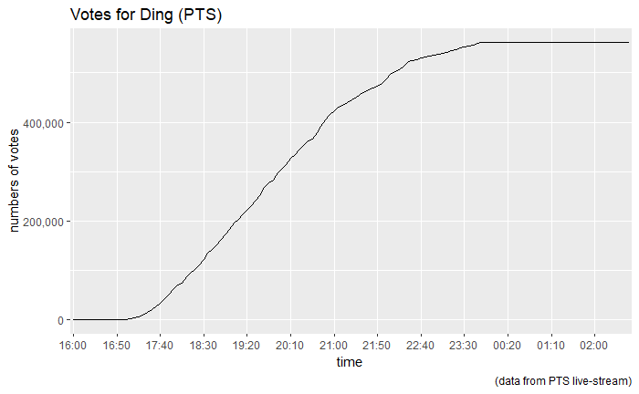

```r
#PTS data
PTS <- read.csv("data/PTS_vote.csv")
##time line in 24-hour based
time = reorder(PTS$time, c(1:129))
PTS <- data.frame(time = time, Ding = PTS$PTS_1, Ko = PTS$PTS_2)
ggplot(data = PTS) +
  geom_line(mapping =  aes(x = time, y = Ding, group = 1)) +
  labs(x = "time ", y = "numbers of votes",
       title = "Votes for Ding (PTS)", caption = "(data from PTS live-stream)") +
  scale_x_discrete(breaks = PTS$time[seq(1, 129, by = 10)]) +
  scale_y_continuous(labels= scales::comma)
```

```r
NA
```

## data form CEC

The official data for election is published at [Official Site](http://db.cec.gov.tw/). We first manually extract the data for Taipei mayor election into the Exel file, and read it:

```r
CEC_endtime <- read.csv("data/CEC_time.csv", as.is=TRUE)
CEC_endtime <- CEC_endtime[CEC_endtime$X == "taipei",]
CEC_endtime
```

|  | X | location | date | time |
| --- | --- | --- | --- | --- |
| 1 | taipei | 1 | 11月24日 | 22:10 |
| 2 | taipei | 2 | 11月24日 | 19:54 |
| 3 | taipei | 3 | 11月24日 | 21:53 |
| 4 | taipei | 4 | 11月24日 | 23:34 |
| 5 | taipei | 5 | 11月24日 | 23:01 |
| 6 | taipei | 6 | 11月24日 | 23:14 |
| 7 | taipei | 7 | 11月24日 | 21:29 |
| 8 | taipei | 8 | 11月24日 | 21:21 |
| 9 | taipei | 9 | 11月24日 | 21:02 |
| 10 | taipei | 10 | 11月24日 | 20:29 |

[output cut: 990 more lines]

```r
CEC_vote <- read.csv("data/CEC_vote.csv")
CEC_vote
```

| location | ding | yao | ke | effetive | dilivered | elector | voting_rate |
| --- | --- | --- | --- | --- | --- | --- | --- |
| 1 | 338 | 196 | 316 | 862 | 871 | 1,288 | 67.62 |
| 2 | 326 | 243 | 412 | 988 | 999 | 1,362 | 73.35 |
| 3 | 247 | 144 | 306 | 702 | 711 | 1,039 | 68.43 |
| 4 | 282 | 177 | 307 | 775 | 779 | 1,175 | 66.30 |
| 5 | 315 | 183 | 378 | 886 | 890 | 1,289 | 68.97 |
| 6 | 306 | 194 | 340 | 847 | 849 | 1,220 | 69.59 |
| 7 | 348 | 214 | 478 | 1,045 | 1,047 | 1,538 | 68.08 |
| 8 | 367 | 215 | 428 | 1,019 | 1,030 | 1,540 | 66.88 |
| 9 | 337 | 199 | 427 | 972 | 981 | 1,444 | 67.94 |
| 10 | 347 | 174 | 396 | 923 | 928 | 1,423 | 65.21 |

[output cut: 990 more lines]

### model for CEC’s data

Because the data only contains the total votes and the finished time for each observation post, we have to find anothe wayr to build the data in order to be compared with others.

We assume :

```
  1. the volocity of counting the valid was fixed,
  2. all post begins the procedure in time, and
  3.the volocity of counting the valid was fixed
```

. We then use the average rate of velocity for each post to build a model where all timely votes were summed together to form a total votes model for every 5 minutes.

```r
##convert the 24-based into how many 5 minutes after 16:00
standardlize_unit <- function(t){
  hour <- as.integer(substr(t,1,2))
  min  <- as.integer(substr(t,4,5))
  for(i in 1:length(hour)){
    if(hour[i] < 8){
      hour[i] = hour[i]+24
    }
  }
  ##official procedure starts from 17:00
  hour = hour-17
  return ((60*hour+min)/5)
}
##the end time fro each observation post
end_time <- standardlize_unit(CEC_endtime$time)
head(end_time)
```

```
[1] 62.0 34.8 58.6 78.8 72.2 74.8
```

```r
##the rate for each observation post
rate <- CEC_vote[,c(2,4)]/end_time
rate
```

| ding | ke |
| --- | --- |
| 5.451613 | 5.096774 |
| 9.367816 | 11.839080 |
| 4.215017 | 5.221843 |
| 3.578680 | 3.895939 |
| 4.362881 | 5.235457 |
| 4.090909 | 4.545455 |
| 6.468401 | 8.884758 |
| 7.030651 | 8.199234 |
| 6.962810 | 8.822314 |
| 8.301435 | 9.473684 |

[output cut: 990 more lines]

now we have built a model with timely total votes by accoumulating all instantaneous votes in accordance with time.

```r
sum_model <- function(r, t){
  total <- vector(mode = "numeric", length = 116) ##17:00~02:40
  length(total)
  #time
  for(i in 1:117){

    #station
    for(j in 1:length(r)){
      if(t[j] > i){
        total[i] = total[i] + i*r[j]
      } else if(t[j] < i) {
        total[i] = total[i] + t[j]*r[j]

      }
      if(floor(t[j]) == i) {
        total[i] = total[i] +  (t[j]-i)*r[j]
      }
    }
  }
  return (total)
}
window12 <- vector(mode = "double", length = 12)
CEC <- data.frame(Ding  = c(window12, sum_model(rate$ding , end_time)), Ke = c(window12,sum_model(rate$ke, end_time)))
```

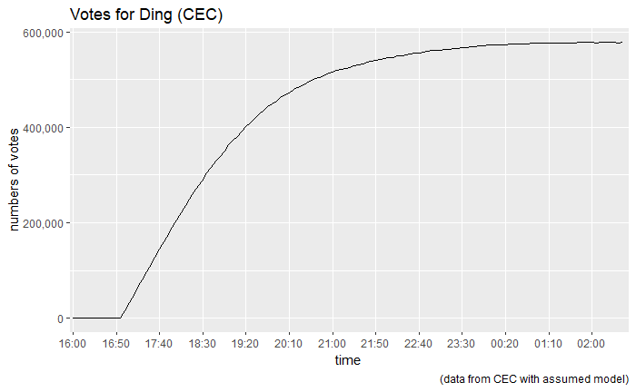

```r
## plot the number of votes based on time
ggplot(data = CEC) +
  geom_line(mapping =  aes(x = t, y = Ding, group = 1)) +
  labs(x = "time ", y = "numbers of votes",
       title = "Votes for Ding (CEC)", caption = "(data from CEC with assumed model)") +
  scale_x_discrete(breaks = PTS$time[seq(1, 129, by = 10)]) +
  scale_y_continuous(labels= scales::comma)
```

## Records of votes from different media

With two trustworthy resource to benchmarch with, we then look into the 4 sample media needed to be compared. They are **Taiwan Television Enterprise**, **Sanlih E-Television**, **China Television Company** and **Eastern Home Shopping television**, respectively.

[figure not shown]

```r
media <- read.csv("data/media_vote.csv")
media_Ding <- data.frame(TTV = media$TTV_1, SET = media$SET_1, CTV = media$SET_1, EHS = media$EHS_1)

media_Ko   <- data.frame(TTV = media$TTV_2, SET = media$SET_2, CTV = media$SET_2, EHS = media$EHS_2)
###vote for Ding, Shou-chung and Ko Wen-je
ggplot(data = media_Ding) +
  geom_line(mapping =  aes(x = time, y = TTV, group = 1, size = "4"),color = "#3333CC") +
  geom_line(mapping =  aes(x = time, y = SET, group = 1, size = "4"),color = "#0099CC") +
  geom_line(mapping =  aes(x = time, y = CTV, group = 1, size = "4"),color = "#00FF66") +
  geom_line(mapping =  aes(x = time, y = EHS, group = 1, size = "4"),color = "#66FFFF") +
  scale_color_discrete(name = "Y FFes", labels = c("TTV", "SET", "CTV", "EHS"))+

  labs(x = "time ", y = "numbers of votes",
       title = "Votes for Ding (CEC)", caption = "(data from CEC with assumed model)") +
  scale_x_discrete(breaks = PTS$time[seq(1, 129, by = 10)]) +
  scale_y_continuous(labels= scales::comma)
```

# Comparision

## compare with PTS

I take PTS as one of the realible source of imformation for several reasons. It is a public boardcasting, and thanks to its durable reputation and the special way of financial soruce of funding, it is unlikely to has incentive to stream false information. All in all, PTS is more credible in a lot of sense.

When we take a look at the graph below, we can see an obvious over-estimation for the votes of *Ting* from the rest of the media(other than red).

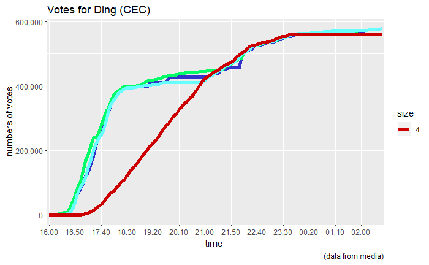

```r
ggplot(data = media_Ding) +
  geom_line(mapping =  aes(x = time, y = TTV, group = 1, size = "4"),color = "#3333CC") +
  geom_line(mapping =  aes(x = time, y = SET, group = 1, size = "4"),color = "#0099CC") +
  geom_line(mapping =  aes(x = time, y = CTV, group = 1, size = "4"),color = "#00FF66") +
  geom_line(mapping =  aes(x = time, y = EHS, group = 1, size = "4"),color = "#66FFFF") +

  geom_line(mapping =  aes(x = time, y = PTS$Ding, group =1, size = "4"), color="#CC0000")+
  scale_colour_manual(name="Line Color",
    values=c(myline1="#3333CC", myline2="#0099CC", myline3="#00FF66", myline4="#66FFFF", myline5 = "#CC0000"))+
  labs(x = "time ", y = "numbers of votes", title = "Votes for Ding (CEC)", caption = "(data from media)") +
  scale_x_discrete(breaks = PTS$time[seq(1, 129, by = 10)]) +
  scale_y_continuous(labels= scales::comma)
```

The result is same as it comes to current mayor Ko’s votes. The media apart from PTS report a ever–flowing votes until they suddenly converged to the real vote population late in the event.

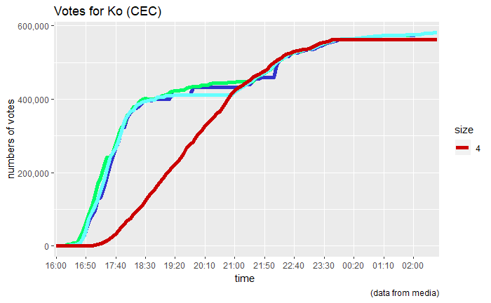

```r
ggplot(data = media_Ko) +
  geom_line(mapping =  aes(x = time, y = TTV, group = 1, size = "4"),color = "#3333CC") +
  geom_line(mapping =  aes(x = time, y = SET, group = 1, size = "4"),color = "#0099CC") +
  geom_line(mapping =  aes(x = time, y = CTV, group = 1, size = "4"),color = "#00FF66") +
  geom_line(mapping =  aes(x = time, y = EHS, group = 1, size = "4"),color = "#66FFFF") +


  geom_line(mapping =  aes(x = t, y = PTS$Ko,group = 1, size = "4"), color="#CC0000")+

  labs(x = "time ", y = "numbers of votes",
       title = "Votes for Ko (CEC)", caption = "(data from media)") +
  scale_x_discrete(breaks = PTS$time[seq(1, 129, by = 10)]) +
  scale_y_continuous(labels= scales::comma)
```

Indeed, saying PTS having less motivates to exaggerate the number is not enough to conclude the accuracy of their estimation on votes. After all, PTS was estimating the votes on their own. We only see that a significant difference exists between the way of counting votes of different media. As the result, we need a another way to confirm whether others media lies or not.

## compare with CEC model

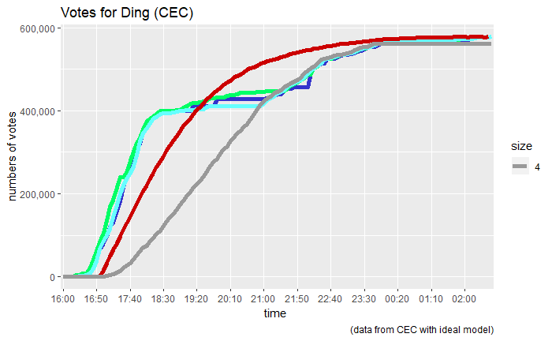

```r
ggplot(data = media_Ding) +
  geom_line(mapping =  aes(x = time, y = TTV, group = 1, size = "4"),color = "#3333CC") +
  geom_line(mapping =  aes(x = time, y = SET, group = 1, size = "4"),color = "#0099CC") +
  geom_line(mapping =  aes(x = time, y = CTV, group = 1, size = "4"),color = "#00FF66") +
  geom_line(mapping =  aes(x = time, y = EHS, group = 1, size = "4"),color = "#66FFFF") +

  geom_line(mapping =  aes(x = t, y = CEC$Ding, group = 1, size = "4"), color = "#CC0000") +
  geom_line(mapping =  aes(x = t, y = PTS$Ding, group = 1, size = "4"), color = "#999999") +

  labs(x = "time ", y = "numbers of votes",
       title = "Votes for Ding (CEC)", caption = "(data from CEC with ideal model)") +
  scale_x_discrete(breaks = PTS$time[seq(1, 129, by = 10)]) +
  scale_y_continuous(labels= scales::comma)
```

Same is Ko’s votes.

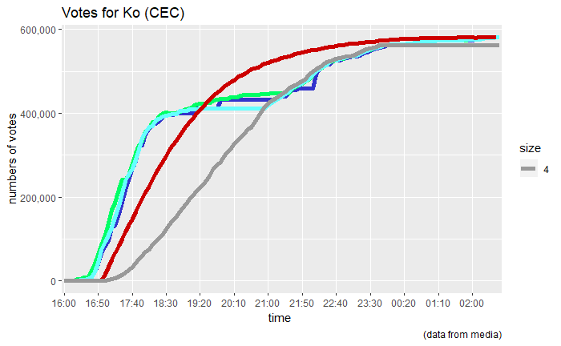

```r
ggplot(data = media_Ko) +
  geom_line(mapping =  aes(x = time, y = TTV, group = 1, size = "4"),color = "#3333CC") +
  geom_line(mapping =  aes(x = time, y = SET, group = 1, size = "4"),color = "#0099CC") +
  geom_line(mapping =  aes(x = time, y = CTV, group = 1, size = "4"),color = "#00FF66") +
  geom_line(mapping =  aes(x = time, y = EHS, group = 1, size = "4"),color = "#66FFFF") +

  geom_line(mapping =  aes(x = t, y = CEC$Ke, group = 1, size = "4"), color = "#CC0000") +
  geom_line(mapping =  aes(x = t, y = PTS$Ko, group = 1, size = "4"), color = "#999999") +
  labs(x = "time ", y = "numbers of votes",
       title = "Votes for Ko (CEC)", caption = "(data from media)") +
  scale_x_discrete(breaks = PTS$time[seq(1, 129, by = 10)]) +
  scale_y_continuous(labels= scales::comma)
```

### Bounding Method - idealized curve

The result is much more interesting when it comes to this CEC model. Remember that CEC only offered a discreat form of data - **the time when the observation post end** and **the total votes of each post**. Different post may have different size, staff, and thus different rate of counting the vote. Therefore, it is impposible to take account for all the variation that may happened in the event. Therefore, we have no alternative but to find another model to represent the voting in reality.

The way we built the model is by assuming every things is in time and fixed, which is not possible. As we know, any human-associated process cannot avoid overhead or inefficiency, especially being in national scale like mayor election, not to mention there was also a big referendum event held on 11/24, creating a huge snurl-up in every observation post. It will not be surprise to see the real curve for votes will be gentler, in which many observation post delayed.

### Evidence - overestimated votes

Given the above conditions, it is very unlikely the votes in reality have any chance to exceed the modeled curve. And the fact that all the sample data, except for PTS, have an overflows of votes during the rushing hour(16:00~20:00), give us conviction to accuse these media of forging statistics, which is totally not surprising.

# Conclusion

Those votes data from sample media differs with that of PTS’s. Since PTS is a more realible source in terms of reputation, a doubt was incured on the creditibility of sample media. Moreover, with the idealized model generated from the real data from CEC, and a bit induction, we have evidence to conclude an overstatement of votes from media.